# Deploying a ML model to predict Fertility outcomes in patient undergoing gamete banking A national SART database

Rstudioyf 2022-12-01

## Introduction

There has been a substantial increase in gamete banking in the last decade, various studies have showed that apart from the scale of this trend, the demographics of women opting for gamete banking has shifted to a younger age group. Success in these cycles is not well defined and the prediction of number of women who eventually returned to use their cryopreserved gametes has been consistently low making an individualized prognosis and counseling using various approaches largely unsuccessful.

## Objective

Data of interest: Clinical and embryonic data of patients who underwent gamete banking were used. To model the number of oocytes needed to bank and to predict the estimated storage time, we will used logistic regression (model 1) and a stepwise regression (model 2/primary) as methods for selection. The predictive model will be assessed against a test set. The model discrimination and calibration will be tested by ROC curve. Our final model will output the individualized probability based on the predictors. A web-based calculator will be developed to make two types of predictions automatically: 1. Onco-fertility and PGT-M indications and 2. elective Oocyte freezing cycles. This new banking calculator may assist in clinical counseling and in individualized treatment planning and could better address aspects such as the time number of oocytes and cycles required in order to maximize chances for a live birth.

## Aims and anticipated outcome

Train test and validate a prediction model based on a national SART dataset. This predictive tool, based on multiple predictors and banking indications will assist in an individual counseling and will produce an estimate of the optimum number of oocytes and cycles needed. Moreover, the tool will estimate the probability and time interval for claiming the gametes.

Methods: A retrospective cohort analysis. Clinical data were extracted at from the national SART database https://www.sart.org/. We included all women undergoing autologous oocyte or embryo banking procedures, who had their first oocyte retrieval from December 2014 to December 2020 and came back to claim their gametes for intended pregnancy.

Cohort description: Our database includes information contained in electronic charts derived most IVF clinic in the USA, from a female population. Data of interest included patient’s demographics, past medical history, and infertility evaluation including diagnosis, laboratory testing for ovarian reserve, and any radiologic studies pertinent to a diagnosis of infertility.

Definition of outcomes: We aimed to predict live birth among those who came to claim their gametes (task 1). The response variable “live birth” is coded 0 for no live birth and 1 for live birth.

## Upload data

```r
library(readr)
bank.linked_df <- read.csv("C:\\Users\\Youval Fouks\\Desktop\\Practicum\\CSV\\Linked 2022 SART Data.csv")
```

## Install & load packages

Preprocessing: Redundancy of the data was treated with variable Selection in order to reach better predictors for the modeling phase. Redundant and highly correlated variables exclusion was made (by clinical judgment).

## Remove unnecessary cols

rename variables

recode var and recode to missing data

```r
df[df == "N"] <- "0"
df[df == "Y"] <- "1"
df[df == "No"] <- "0"
df[df == "Yes"] <- "1"

# recode to missing data
df[df=="NaN"] <- NA
df[df=="N/A"] <- NA
df[df=="Not Reported"] <- NA
df[df == "Not Entered"] <- NA
df[df == ""] <- NA
df[df == "NULL"] <- NA
```

Missingness in data

```r
naniar::miss_var_summary(df)
```

```
## # A tibble: 124 × 3
##    variable                                                       n_miss pct_m…¹
##    <chr>                                                           <int>   <dbl>
##  1 gender.dysphoria                                                 6872     100
##  2 DO                                                               6872     100
##  3 OocyteThawDateStartDateDiff_Until2013Only                        6872     100
##  4 ThawedOocyteRetrievalToCryoPreservationDateDiff_Until2013Only    6872     100
##  5 ThawedOocyteDonorRetrievalToCryoPreservationDateDiff_Until201…   6872     100
##  6 StartDateFreezeDateDiff_AutologousRetrieval2_Freeze3_3_Autolo…   6872     100
##  7 StartDateFreezeDateDiff_AutologousRetrieval4_Freeze3_3_Autolo…   6872     100
##  8 RetrievalDateStartDateDiff_AutologousRetrieval5                  6872     100
##  9 StartDateFreezeDateDiff_AutologousRetrieval5_Freeze2_2_Autolo…   6872     100
## 10 StartDateFreezeDateDiff_AutologousRetrieval5_Freeze3_3_Autolo…   6872     100
## # … with 114 more rows, and abbreviated variable name ¹pct_miss
```

```r
df <- df[,colSums(is.na(df))<nrow(df)]
naniar::miss_var_summary(df)
```

```
## # A tibble: 109 × 3
##    variable                                                       n_miss pct_m…¹
##    <chr>                                                           <int>   <dbl>
##  1 StartDateFreezeDateDiff_AutologousRetrieval3_Freeze3_3_Autolo…   6871   100.
##  2 StartDateFreezeDateDiff_AutologousRetrieval4_Freeze2_2_Autolo…   6871   100.
##  3 StartDateFreezeDateDiff_AutologousRetrieval3_Freeze2_2_Autolo…   6870   100.
##  4 Medical.Tumor.prevention                                         6869   100.
##  5 StartDateFreezeDateDiff_AutologousRetrieval6                     6869   100.
##  6 TransferDateRetrievalDateDiff_AutologousRetrieval6               6869   100.
##  7 RetrievalDateStartDateDiff_AutologousRetrieval4                  6868    99.9
##  8 OocytesCryoed_AutologousRetrieval4                               6868    99.9
##  9 StartDateFreezeDateDiff_AutologousRetrieval2_Freeze2_2_Autolo…   6867    99.9
## 10 StartDateFreezeDateDiff_AutologousRetrieval6_Freeze1_1_Autolo…   6867    99.9
## # … with 99 more rows, and abbreviated variable name ¹pct_miss
```

Remove splitted cycles

```r
df_no_fresh <- df[!(df$RetrievalType_AutologousRetrieval1=="Fresh"),]
df <- df_no_fresh
```

## Descriptive table

```r
Table1 <- tableby(PregnancyOutcome_Live.Birth ~ Age + Clinic.Region.USA + Gravidity +  FullTermBirths + PreTermBirths + MaleInfertility + Endometriosis + PolycysticOvaries +  DiminishedOvarianReserve + TubalLigation + Uterine + Unexplained + as.factor(elect) +  as.factor(Onco) +  as.factor(Medical.benign) +    as.factor(Syndromatic.DOR) +  as.factor(DOR..35) ,data=df)
```

```r
Table2 <- tableby(C ~ ThawedEmbryo + ThawedOocyte + SpermSource_Partner + SpermSource_Donor + SpermSource_Mixed + TransferAttempted + TreatmentOutcome_Not.Pregnant + TreatmentOutcome_Biochemical + TreatmentOutcome_Clinical.Intrauterine.Gestation + PregnancyOutcome_Outcome.Unknown + PregnancyOutcome_Live.Birth + Pregnancy.Loss.Abortion ,data=df)

##########unknowen and 2PN excluded
#summary(tab1, text=TRUE)
summary(Table1)
```

```
##
##
## |                               |   0 (N=4192)    |   1 (N=2346)    | Total (N=6538)  | p value|
## |:------------------------------|:---------------:|:---------------:|:---------------:|-------:|
## |**Age**                        |                 |                 |                 | < 0.001|
## |&nbsp;&nbsp;&nbsp;Mean (SD)    | 35.822 (5.137)  | 33.745 (4.620)  | 35.077 (5.056)  |        |
## |&nbsp;&nbsp;&nbsp;Range        | 22.000 - 53.000 | 18.000 - 48.000 | 18.000 - 53.000 |        |
## |**Clinic.Region.USA**          |                 |                 |                 | < 0.001|
## |&nbsp;&nbsp;&nbsp;Midwest      |   726 (17.3%)   |   378 (16.1%)   |  1104 (16.9%)   |        |
## |&nbsp;&nbsp;&nbsp;Northeast    |  1143 (27.3%)   |   483 (20.6%)   |  1626 (24.9%)   |        |
## |&nbsp;&nbsp;&nbsp;South        |  1519 (36.2%)   |  1001 (42.7%)   |  2520 (38.5%)   |        |
## |&nbsp;&nbsp;&nbsp;West         |   804 (19.2%)   |   484 (20.6%)   |  1288 (19.7%)   |        |
## |**Gravidity**                  |                 |                 |                 |   0.213|
## |&nbsp;&nbsp;&nbsp;>10          |    1 (0.0%)     |    0 (0.0%)     |    1 (0.0%)     |        |
## |&nbsp;&nbsp;&nbsp;0            |  2024 (48.3%)   |  1110 (47.3%)   |  3134 (47.9%)   |        |
## |&nbsp;&nbsp;&nbsp;1            |  1051 (25.1%)   |   628 (26.8%)   |  1679 (25.7%)   |        |
## |&nbsp;&nbsp;&nbsp;10           |    1 (0.0%)     |    1 (0.0%)     |    2 (0.0%)     |        |
## |&nbsp;&nbsp;&nbsp;2            |   566 (13.5%)   |   333 (14.2%)   |   899 (13.8%)   |        |
## |&nbsp;&nbsp;&nbsp;3            |   293 (7.0%)    |   156 (6.6%)    |   449 (6.9%)    |        |
## |&nbsp;&nbsp;&nbsp;4            |   133 (3.2%)    |    70 (3.0%)    |   203 (3.1%)    |        |
## |&nbsp;&nbsp;&nbsp;5            |    55 (1.3%)    |    28 (1.2%)    |    83 (1.3%)    |        |
## |&nbsp;&nbsp;&nbsp;6            |    39 (0.9%)    |    9 (0.4%)     |    48 (0.7%)    |        |
## |&nbsp;&nbsp;&nbsp;7            |    15 (0.4%)    |    3 (0.1%)     |    18 (0.3%)    |        |
## |&nbsp;&nbsp;&nbsp;8            |    4 (0.1%)     |    5 (0.2%)     |    9 (0.1%)     |        |
## |&nbsp;&nbsp;&nbsp;9            |    1 (0.0%)     |    0 (0.0%)     |    1 (0.0%)     |        |
## |&nbsp;&nbsp;&nbsp;Unknown      |    9 (0.2%)     |    3 (0.1%)     |    12 (0.2%)    |        |
## |**FullTermBirths**             |                 |                 |                 |   0.002|
## |&nbsp;&nbsp;&nbsp;N-Miss       |      2033       |      1113       |      3146       |        |
## |&nbsp;&nbsp;&nbsp;0            |  1084 (50.2%)   |   535 (43.4%)   |  1619 (47.7%)   |        |
## |&nbsp;&nbsp;&nbsp;1            |   825 (38.2%)   |   547 (44.4%)   |  1372 (40.4%)   |        |
## |&nbsp;&nbsp;&nbsp;2            |   167 (7.7%)    |   113 (9.2%)    |   280 (8.3%)    |        |
## |&nbsp;&nbsp;&nbsp;3            |    50 (2.3%)    |    30 (2.4%)    |    80 (2.4%)    |        |
## |&nbsp;&nbsp;&nbsp;4            |    25 (1.2%)    |    7 (0.6%)     |    32 (0.9%)    |        |
## |&nbsp;&nbsp;&nbsp;5            |    6 (0.3%)     |    1 (0.1%)     |    7 (0.2%)     |        |
## |&nbsp;&nbsp;&nbsp;7            |    1 (0.0%)     |    0 (0.0%)     |    1 (0.0%)     |        |
## |&nbsp;&nbsp;&nbsp;8            |    1 (0.0%)     |    0 (0.0%)     |    1 (0.0%)     |        |
## |**PreTermBirths**              |                 |                 |                 |   0.145|
## |&nbsp;&nbsp;&nbsp;N-Miss       |      2033       |      1113       |      3146       |        |
## |&nbsp;&nbsp;&nbsp;0            |  1976 (91.5%)   |  1146 (92.9%)   |  3122 (92.0%)   |        |
## |&nbsp;&nbsp;&nbsp;1            |   157 (7.3%)    |    83 (6.7%)    |   240 (7.1%)    |        |
```

[output cut: 25 more lines]

```
## |**as.factor(elect)**           |                 |                 |                 | < 0.001|
## |&nbsp;&nbsp;&nbsp;N-Miss       |       505       |       336       |       841       |        |
## |&nbsp;&nbsp;&nbsp;1            |  3687 (100.0%)  |  2010 (100.0%)  |  5697 (100.0%)  |        |
## |**as.factor(Onco)**            |                 |                 |                 |   0.002|
## |&nbsp;&nbsp;&nbsp;N-Miss       |      4158       |      2333       |      6491       |        |
## |&nbsp;&nbsp;&nbsp;1            |   34 (100.0%)   |   13 (100.0%)   |   47 (100.0%)   |        |
## |**as.factor(Medical.benign)**  |                 |                 |                 | < 0.001|
## |&nbsp;&nbsp;&nbsp;N-Miss       |      3848       |      2141       |      5989       |        |
## |&nbsp;&nbsp;&nbsp;1            |  344 (100.0%)   |  205 (100.0%)   |  549 (100.0%)   |        |
## |**as.factor(Syndromatic.DOR)** |                 |                 |                 |   0.003|
## |&nbsp;&nbsp;&nbsp;N-Miss       |      4174       |      2342       |      6516       |        |
## |&nbsp;&nbsp;&nbsp;1            |   18 (100.0%)   |   4 (100.0%)    |   22 (100.0%)   |        |
## |**as.factor(DOR..35)**         |                 |                 |                 | < 0.001|
## |&nbsp;&nbsp;&nbsp;N-Miss       |      4043       |      2271       |      6314       |        |
## |&nbsp;&nbsp;&nbsp;1            |  149 (100.0%)   |   75 (100.0%)   |  224 (100.0%)   |        |
```

```r
summary(Table2)
```

```
##
##
## |                                                     |  0 (N=2344)   |  1 (N=4194)   | Total (N=6538) | p value|
## |:----------------------------------------------------|:-------------:|:-------------:|:--------------:|-------:|
## |**ThawedEmbryo**                                     |               |               |                | < 0.001|
## |&nbsp;&nbsp;&nbsp;0                                  |  605 (25.8%)  | 2116 (50.5%)  |  2721 (41.6%)  |        |
## |&nbsp;&nbsp;&nbsp;1                                  | 1739 (74.2%)  | 2078 (49.5%)  |  3817 (58.4%)  |        |
## |**ThawedOocyte**                                     |               |               |                | < 0.001|
## |&nbsp;&nbsp;&nbsp;0                                  | 1727 (73.7%)  | 2048 (48.8%)  |  3775 (57.7%)  |        |
## |&nbsp;&nbsp;&nbsp;1                                  |  617 (26.3%)  | 2146 (51.2%)  |  2763 (42.3%)  |        |
## |**SpermSource_Partner**                              |               |               |                | < 0.001|
## |&nbsp;&nbsp;&nbsp;0                                  | 1884 (80.4%)  | 2501 (59.6%)  |  4385 (67.1%)  |        |
## |&nbsp;&nbsp;&nbsp;1                                  |  460 (19.6%)  | 1693 (40.4%)  |  2153 (32.9%)  |        |
## |**SpermSource_Donor**                                |               |               |                | < 0.001|
## |&nbsp;&nbsp;&nbsp;0                                  | 2190 (93.4%)  | 3752 (89.5%)  |  5942 (90.9%)  |        |
## |&nbsp;&nbsp;&nbsp;1                                  |  154 (6.6%)   |  442 (10.5%)  |   596 (9.1%)   |        |
## |**SpermSource_Mixed**                                |               |               |                |   0.296|
## |&nbsp;&nbsp;&nbsp;0                                  | 2342 (99.9%)  | 4186 (99.8%)  |  6528 (99.8%)  |        |
## |&nbsp;&nbsp;&nbsp;1                                  |   2 (0.1%)    |   8 (0.2%)    |   10 (0.2%)    |        |
## |**TransferAttempted**                                |               |               |                | < 0.001|
## |&nbsp;&nbsp;&nbsp;0                                  |   3 (0.1%)    |  873 (20.8%)  |  876 (13.4%)   |        |
## |&nbsp;&nbsp;&nbsp;1                                  | 2341 (99.9%)  | 3321 (79.2%)  |  5662 (86.6%)  |        |
## |**TreatmentOutcome_Not.Pregnant**                    |               |               |                | < 0.001|
## |&nbsp;&nbsp;&nbsp;0                                  | 2344 (100.0%) | 1161 (27.7%)  |  3505 (53.6%)  |        |
## |&nbsp;&nbsp;&nbsp;1                                  |   0 (0.0%)    | 3033 (72.3%)  |  3033 (46.4%)  |        |
## |**TreatmentOutcome_Biochemical**                     |               |               |                | < 0.001|
## |&nbsp;&nbsp;&nbsp;0                                  | 2344 (100.0%) | 3611 (86.1%)  |  5955 (91.1%)  |        |
## |&nbsp;&nbsp;&nbsp;1                                  |   0 (0.0%)    |  583 (13.9%)  |   583 (8.9%)   |        |
## |**TreatmentOutcome_Clinical.Intrauterine.Gestation** |               |               |                | < 0.001|
## |&nbsp;&nbsp;&nbsp;0                                  |   1 (0.0%)    | 3645 (86.9%)  |  3646 (55.8%)  |        |
## |&nbsp;&nbsp;&nbsp;1                                  | 2343 (100.0%) |  549 (13.1%)  |  2892 (44.2%)  |        |
## |**PregnancyOutcome_Outcome.Unknown**                 |               |               |                |   0.003|
## |&nbsp;&nbsp;&nbsp;0                                  | 2344 (100.0%) | 4178 (99.6%)  |  6522 (99.8%)  |        |
## |&nbsp;&nbsp;&nbsp;1                                  |   0 (0.0%)    |   16 (0.4%)   |   16 (0.2%)    |        |
## |**PregnancyOutcome_Live.Birth**                      |               |               |                | < 0.001|
## |&nbsp;&nbsp;&nbsp;0                                  |   0 (0.0%)    | 4192 (100.0%) |  4192 (64.1%)  |        |
## |&nbsp;&nbsp;&nbsp;1                                  | 2344 (100.0%) |   2 (0.0%)    |  2346 (35.9%)  |        |
## |**Pregnancy.Loss.Abortion**                          |               |               |                | < 0.001|
## |&nbsp;&nbsp;&nbsp;0                                  | 2344 (100.0%) | 3676 (87.6%)  |  6020 (92.1%)  |        |
## |&nbsp;&nbsp;&nbsp;1                                  |   0 (0.0%)    |  518 (12.4%)  |   518 (7.9%)   |        |
```

Sum retrival cycles into sum

```r
df$Retrieval_1 <-ifelse(df$ThawDateStartDateDiff_AutologousRetrieval1 == "NA" , 0, 1)
df$Retrieval_2 <-ifelse(df$ThawDateStartDateDiff_AutologousRetrieval2 == "NA" , 0, 1)
df$Retrieval_3 <-ifelse(df$ThawDateStartDateDiff_AutologousRetrieval3 == "NA" , 0, 1)
df$Retrieval_4 <-ifelse(df$ThawDateStartDateDiff_AutologousRetrieval4 == "NA" , 0, 1)
df$Retrieval_5 <-ifelse(df$ThawDateStartDateDiff_AutologousRetrieval5 == "NA" , 0, 1)
df$Retrieval_6 <-ifelse(df$ThawDateStartDateDiff_AutologousRetrieval6 == "NA" , 0, 1)

df <- df %>%
  mutate(sum_1 = rowSums(across(c(Retrieval_1, Retrieval_2, Retrieval_3, Retrieval_4, Retrieval_5, Retrieval_6)), na.rm=TRUE))
```

Number of retrievals against the results

```r
Table3 <- tableby(C ~ as.factor(sum_1) ,data=df)
##########unknowen and 2PN excluded
#summary(tab1, text=TRUE)
summary(Table3)
```

```
##
##
## |                     |  0 (N=2344)  |  1 (N=4194)  | Total (N=6538) | p value|
## |:--------------------|:------------:|:------------:|:--------------:|-------:|
## |**as.factor(sum_1)** |              |              |                | < 0.001|
## |&nbsp;&nbsp;&nbsp;1  | 2247 (95.9%) | 3853 (91.9%) |  6100 (93.3%)  |        |
## |&nbsp;&nbsp;&nbsp;2  |  82 (3.5%)   |  258 (6.2%)  |   340 (5.2%)   |        |
## |&nbsp;&nbsp;&nbsp;3  |  13 (0.6%)   |  63 (1.5%)   |   76 (1.2%)    |        |
## |&nbsp;&nbsp;&nbsp;4  |   2 (0.1%)   |  10 (0.2%)   |   12 (0.2%)    |        |
## |&nbsp;&nbsp;&nbsp;5  |   0 (0.0%)   |   4 (0.1%)   |    4 (0.1%)    |        |
## |&nbsp;&nbsp;&nbsp;6  |   0 (0.0%)   |   6 (0.1%)   |    6 (0.1%)    |        |
```

```r
df <- df %>%
  mutate(sum_2 = rowSums(across(c(Time_to.claim_1, Time_to.claim_2, Time_to.claim_3, Time_to.claim_4, Time_to.claim_5, Time_to.claim_6)), na.rm=TRUE))

names(df)[111]=paste("Time_to.claim")
```

Trim all in between cycles after aggregating the data

```
## # A tibble: 63 × 3
##    variable                                        n_miss pct_miss
##    <chr>                                            <int>    <dbl>
##  1 RetrievalDateStartDateDiff_AutologousRetrieval1   6538    100
##  2 Medical.Tumor.prevention                          6535    100.
##  3 Syndromatic.DOR                                   6516     99.7
##  4 Onco                                              6491     99.3
##  5 DOR..35                                           6314     96.6
##  6 OtherReasonRFA                                    6037     92.3
##  7 Medical.benign                                    5989     91.6
##  8 Unknowen                                          5930     90.7
##  9 StartDateFreezeDateDiff_AutologousRetrieval1      4933     75.5
## 10 NumberBorn                                        4179     63.9
## # … with 53 more rows
```

## Missing values

I have been faced with missing data of various extent. After removing structural missingness, we have summed our missing percentages that in some cases has reached 11%.

Treatment for missing data: First: for each attribute, I test for the correlation of missingness with the outcome and explore with the clinician (my boss) whether or not missingness could potentially encode for a certain prognosis. After solving all structural missingness, I have checked for relations between target and potentially imputed variables (scatter kNN). Using kNN-imputation (k=20) for treating missing data and to control noise in the data by assigning values to miss data based on the closest class or cluster that does not have a missing value.

Treat structural missingness

```r
df.big.trim$FullTermBirths <- ifelse(df.big.trim$Gravidity == 0 , 0, df.big.trim$FullTermBirths)
df.big.trim$PreTermBirths <- ifelse(df.big.trim$Gravidity == 0 , 0, df.big.trim$PreTermBirths)
df.big.trim$BiochemicalPregnancies <- ifelse(df.big.trim$Gravidity == 0 , 0, df.big.trim$BiochemicalPregnancies)
df.big.trim$SpontaneousAbortions <- ifelse(df.big.trim$Gravidity == 0 , 0, df.big.trim$SpontaneousAbortions)

df.big.trim$NumberBorn[is.na(df.big.trim$NumberBorn)] <- 0
df.big.trim$NumberLiveBorn[is.na(df.big.trim$NumberLiveBorn)] <- 0

df.big.trim$Unknowen[is.na(df.big.trim$Unknowen)] <- 0
df.big.trim$elect[is.na(df.big.trim$elect)] <- 0
df.big.trim$Onco[is.na(df.big.trim$Onco)] <- 0
df.big.trim$Medical.benign[is.na(df.big.trim$Medical.benign)] <- 0
df.big.trim$Medical.Tumor.prevention[is.na(df.big.trim$Medical.Tumor.prevention)] <- 0
df.big.trim$Syndromatic.DOR[is.na(df.big.trim$Syndromatic.DOR)] <- 0
df.big.trim$DOR..35[is.na(df.big.trim$DOR..35)] <- 0
```

## kNN Imputation

kNN Imputation for Missing Values Relations between target and imputed

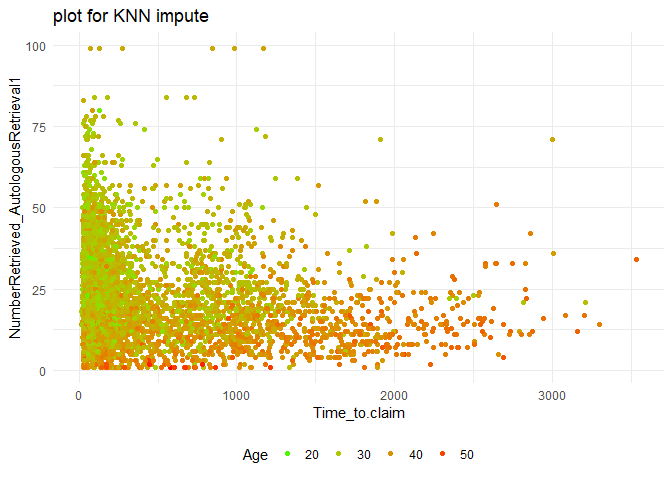

```r
ggplot(df, aes(x = Time_to.claim , y = NumberRetrieved_AutologousRetrieval1, color = Age)) +
  geom_point(show.legend = TRUE) +
  labs(x = 'Time_to.claim', y='NumberRetrieved_AutologousRetrieval1',  title = "plot for KNN impute",
       color = 'Age') +
  scale_color_gradient(low = "green", high = "red",
                       na.value = "blue", guide = "legend") +
  theme_minimal()+theme(legend.position="bottom")
```

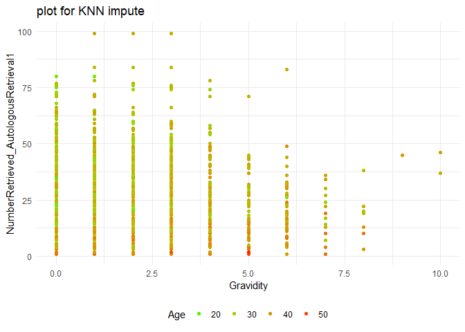

```r
ggplot(df, aes(x = Gravidity , y = NumberRetrieved_AutologousRetrieval1, color = Age)) +
  geom_point(show.legend = TRUE) +
  labs(x = 'Gravidity', y='NumberRetrieved_AutologousRetrieval1',  title = "plot for KNN impute",
       color = 'Age') +
  scale_color_gradient(low = "green", high = "red",
                       na.value = "blue", guide = "legend") +
  theme_minimal()+theme(legend.position="bottom")
```

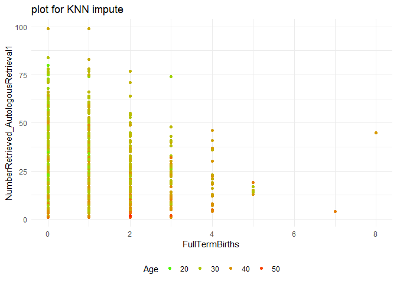

```r
ggplot(df, aes(x = FullTermBirths  , y = NumberRetrieved_AutologousRetrieval1, color = Age)) +
  geom_point(show.legend = TRUE) +
  labs(x = 'FullTermBirths ', y='NumberRetrieved_AutologousRetrieval1',  title = "plot for KNN impute",
       color = 'Age') +
  scale_color_gradient(low = "green", high = "red",
                       na.value = "blue", guide = "legend") +
  theme_minimal()+theme(legend.position="bottom")
```

```r
library(caret)
library(RANN)
preProcValues <- preProcess(df %>%
                          dplyr::select(Time_to.claim, Gravidity, FullTermBirths ,Age,  DonorIdentityKnown, FullTermBirths,  MaleInfertility , elect, DOR..35, SpermSource_Partner, SpermSource_Donor, NumberRetrieved_AutologousRetrieval1, ThawDateStartDateDiff_AutologousRetrieval1 ),
                            method = c("knnImpute"),
                            k = 20,
                            knnSummary = mean)
impute_df_info <- predict(preProcValues, df,na.action = na.pass)

procNames <- data.frame(col = names(preProcValues$mean), mean = preProcValues$mean, sd = preProcValues$std)
for(i in procNames$col){
 impute_df_info[i] <- impute_df_info[i]*preProcValues$std[i]+preProcValues$mean[i]
}
```

```r
df <- impute_df_info
pct_miss(df)
```

```
## [1] 0
```

## Data inspection

```r
library(PerformanceAnalytics)
```

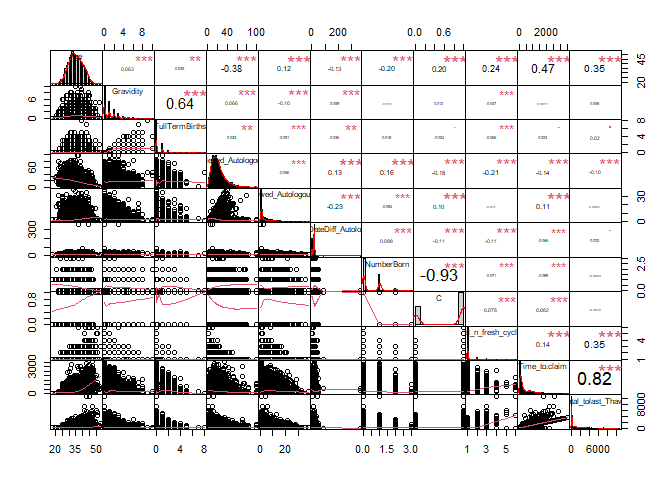

```r
df.numeric <- df %>% dplyr::select(where(is.numeric))
chart.Correlation(df.numeric, histogram=TRUE, pch="+")
```

Model selection: I used logistic regressions as a bassline comparative fit to model Class as a function of my predictors. The first method I used was “all variable included” logistic regression. Then used a stepwise selection process to narrow down the predictors from the initial regression to interpret which factors are the most important to accurately classifying live birth. The predictive ML models were assessed on the basis of the objectives: Penelaized regressions (lasso ridge), Random Forest, and SVM for predicting IVF outcome of live birth.

I have splitted 75% of the data for training using our new factorized variable and the remaining 25% for testing.

Data Partition

```r
## 75% of the sample size
smp_size <- floor(0.75 * nrow(df))

## set the seed
set.seed(2050)
train_ind <- sample(seq_len(nrow(df)), size = smp_size)

train <- df[train_ind, ]
test <- df[-train_ind, ]
```

## Automated regression and logistic regression

stepwise variable selection process to narrow down the predictors in the regression to interpret which factors are the most important to accurately classifying the response variable.

The estimates from logistic regression characterize the relationship between the predictors and response variable on a log-odds scale.

```r
#build models
logreg <- glm(PregnancyOutcome_Live.Birth ~ Clinic.Region.USA + Age +  DonorIdentityKnown +  Gravidity +  FullTermBirths +   MaleInfertility + Endometriosis + PolycysticOvaries + DiminishedOvarianReserve + TubalLigation + TubalHydrosalpinx +
TubalOther + Uterine + Unexplained + OtherNonInfertile +  OtherPGD + Unknowen + elect + DOR..35 + ThawedEmbryo + ThawedOocyte + SpermSource_Partner + SpermSource_Donor + NumberRetrieved_AutologousRetrieval1 +  ThawDateStartDateDiff_AutologousRetrieval1 + Time_to.claim, data = train, family = 'binomial')

logreg_steps <- glm(PregnancyOutcome_Live.Birth ~ Clinic.Region.USA + Age +  DonorIdentityKnown +  Gravidity +  FullTermBirths +   MaleInfertility + Endometriosis + PolycysticOvaries + DiminishedOvarianReserve + TubalLigation + TubalHydrosalpinx +
TubalOther + Uterine + Unexplained + OtherNonInfertile +  OtherPGD + Unknowen + elect + DOR..35 + ThawedEmbryo + ThawedOocyte + SpermSource_Partner + SpermSource_Donor + NumberRetrieved_AutologousRetrieval1 +  ThawDateStartDateDiff_AutologousRetrieval1 + Time_to.claim, data = train, family = 'binomial') %>% stepAIC(trace = F)
step.model <- stepAIC(logreg, trace = FALSE)

#prediction on test data
log.predict <- predict(logreg, newdata = test, type = 'response')
## Warning in predict.lm(object, newdata, se.fit, scale = 1, type = if (type ==
step.predict <- predict(logreg_steps, newdata = test, type = 'response')
```

After training and testing the model, it’s important to understand how well that model did in regards to its accuracy and predictive power. Our models accurately predicted 65% of the observations in the testing set.

## Logistic Regression

```r
#confusion matrix
log.prediction.rd <- ifelse(log.predict > 0.5, 1, 0)
step.prediction <- ifelse(step.predict > .5, 1, 0)

table_2 <- table(log.prediction.rd, test$PregnancyOutcome_Live.Birth)
table_3 <- table(step.prediction, test$PregnancyOutcome_Live.Birth)

Accuracy_logreg <- sum(diag(table_2))/(sum(table_2))
Accuracy_stepwise <- sum(diag(table_3))/(sum(table_3))

labels <- c("Logisitic Regression", "LogReg with Stepwise")
values <- c(Accuracy_logreg, Accuracy_stepwise)

Accuracy_table <- data.frame("Model" = labels, "Accuracy Rate" = values)
Accuracy_table
```

```
##                  Model Accuracy.Rate
## 1 Logisitic Regression     0.6525994
## 2 LogReg with Stepwise     0.6538226
```

Prediction & Confusion Matrix – test data

```r
step.predict <- predict(logreg_steps, newdata = test, type = 'response')
```

A fitted model of the data in which to do predictions now we will check our fit against testing dataset.

summarizing and visualizing regression models

```r
library(jtools)
summ(step.model)
```

| Observations | 4903 |
| --- | --- |
| Dependent variable | PregnancyOutcome_Live.Birth |
| Type | Generalized linear model |
| Family | binomial |
| Link | logit |

| χ²(14) | 441.13 |
| --- | --- |
| Pseudo-R² (Cragg-Uhler) | 0.12 |
| Pseudo-R² (McFadden) | 0.07 |
| AIC | 5996.20 |
| BIC | 6093.66 |

|  | Est. | S.E. | z val. | p |
| --- | --- | --- | --- | --- |
| (Intercept) | 0.95 | 0.33 | 2.82 | 0.00 |
| Clinic.Region.USANortheast | 0.00 | 0.10 | 0.04 | 0.97 |
| Clinic.Region.USASouth | 0.13 | 0.09 | 1.38 | 0.17 |
| Clinic.Region.USAWest | 0.23 | 0.11 | 2.17 | 0.03 |
| Age | -0.05 | 0.01 | -6.49 | 0.00 |
| DonorIdentityKnown1 | 0.21 | 0.14 | 1.56 | 0.12 |
| Gravidity | -0.11 | 0.03 | -3.47 | 0.00 |
| FullTermBirths | 0.16 | 0.06 | 2.73 | 0.01 |
| OtherNonInfertile1 | -0.28 | 0.20 | -1.44 | 0.15 |
| OtherPGD1 | -0.44 | 0.22 | -2.02 | 0.04 |
| ThawedOocyte1 | -0.89 | 0.08 | -11.25 | 0.00 |
| SpermSource_Donor1 | 0.42 | 0.14 | 2.93 | 0.00 |
| NumberRetrieved_AutologousRetrieval1 | 0.01 | 0.00 | 3.90 | 0.00 |
| ThawDateStartDateDiff_AutologousRetrieval1 | 0.00 | 0.00 | 1.50 | 0.13 |
| Time_to.claim | 0.00 | 0.00 | 1.64 | 0.10 |

Standard errors: MLE

## 2 Random Forest

Data Partition

```r
## 75% of the sample size
smp_size <- floor(0.75 * nrow(df))

## set the seed
set.seed(2050)
train_ind <- sample(seq_len(nrow(df)), size = smp_size)

train.x <- df[train_ind, ]
test.x <- df[-train_ind, ]
```

```r
rf1 <- train(PregnancyOutcome_Live.Birth ~ Age + Gravidity +  FullTermBirths + Clinic.Region.USA +  MaleInfertility + Endometriosis  + Uterine + Unexplained +  OtherPGD + Unknowen + elect + Onco + OtherRFA + Medical.benign + Medical.Tumor.prevention + Syndromatic.DOR + SpermSource_Donor + NumberRetrieved_AutologousRetrieval1 +  Time_to.claim + total_n_fresh_cycles,
                    data= train.x ,
                    method ="rf",
                    TuneLength = 5,
                    proximity=TRUE,
                    trControl = trainControl(method = "cv", number=12 ))
# OtherNonInfertile + ThawedEmbryo + TransferAttempted + DonorIdentityKnown  + OtherRFA + SpermSource_Partner
print(rf1)
```

```
## Random Forest
##
## 4903 samples
##   20 predictor
##    2 classes: '0', '1'
##
## No pre-processing
## Resampling: Cross-Validated (12 fold)
## Summary of sample sizes: 4495, 4495, 4494, 4494, 4495, 4495, ...
## Resampling results across tuning parameters:
##
##   mtry  Accuracy   Kappa
##    2    0.6430759  0.01705351
##   12    0.6353329  0.14256025
##   22    0.6349149  0.14741632
##
## Accuracy was used to select the optimal model using the largest value.
## The final value used for the model was mtry = 2.
```

```r
rf1$results
```

```
##   mtry  Accuracy      Kappa  AccuracySD    KappaSD
## 1    2 0.6430759 0.01705351 0.003954829 0.01251731
## 2   12 0.6353329 0.14256025 0.013509730 0.02675366
## 3   22 0.6349149 0.14741632 0.014774287 0.03453317
```

```r
#p.rf <- predict(rf, train.x)
#confusionMatrix(p.rf, train.x$PregnancyOutcome_Live.Birth)
```

```r
library(randomForest)
rf <- randomForest(PregnancyOutcome_Live.Birth ~Age + Gravidity +  FullTermBirths + Clinic.Region.USA +  MaleInfertility + Endometriosis  + Uterine + Unexplained +  OtherPGD + Unknowen + elect + Onco + OtherRFA + Medical.benign + Medical.Tumor.prevention + Syndromatic.DOR + SpermSource_Donor + NumberRetrieved_AutologousRetrieval1 +  Time_to.claim + total_n_fresh_cycles,
                    data= train.x ,
                   TuneLength = 5,
                   importance = T)
# OtherNonInfertile + ThawedEmbryo + TransferAttempted + DonorIdentityKnown  + OtherRFA + SpermSource_Partner
```

Prediction & Confusion Matrix – train data:

```r
p.rf <- predict(rf, train.x)
confusionMatrix(p.rf, train.x$PregnancyOutcome_Live.Birth)
```

```
## Confusion Matrix and Statistics
##
##           Reference
## Prediction    0    1
##          0 3099  343
##          1   39 1422
##
##                Accuracy : 0.9221
##                  95% CI : (0.9142, 0.9294)
##     No Information Rate : 0.64
##     P-Value [Acc > NIR] : < 2.2e-16
##
##                   Kappa : 0.8243
##
##  Mcnemar's Test P-Value : < 2.2e-16
##
##             Sensitivity : 0.9876
##             Specificity : 0.8057
##          Pos Pred Value : 0.9003
##          Neg Pred Value : 0.9733
##              Prevalence : 0.6400
##          Detection Rate : 0.6321
##    Detection Prevalence : 0.7020
##       Balanced Accuracy : 0.8966
##
##        'Positive' Class : 0
##
```

Prediction & Confusion Matrix – test data

```r
p2 <- predict(rf1, test.x)
confusionMatrix(p2, test.x$PregnancyOutcome_Live.Birth)
```

```
## Confusion Matrix and Statistics
##
##           Reference
## Prediction    0    1
##          0 1048  572
##          1    6    9
##
##                Accuracy : 0.6465
##                  95% CI : (0.6228, 0.6697)
##     No Information Rate : 0.6446
##     P-Value [Acc > NIR] : 0.4496
##
##                   Kappa : 0.0125
##
##  Mcnemar's Test P-Value : <2e-16
##
##             Sensitivity : 0.99431
##             Specificity : 0.01549
##          Pos Pred Value : 0.64691
##          Neg Pred Value : 0.60000
##              Prevalence : 0.64465
##          Detection Rate : 0.64098
##    Detection Prevalence : 0.99083
##       Balanced Accuracy : 0.50490
##
##        'Positive' Class : 0
##
```

Variable Importance: These are the variables that the algorithm detected as the most important.

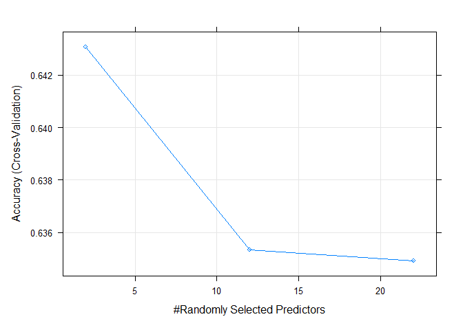

```r
plot(rf1)
```

```r
randomForest::importance(rf)
```

```
##                                               0          1 MeanDecreaseAccuracy
## Age                                  21.1373168 15.1804459          29.32000652
## Gravidity                            12.0829618 -3.9849106           8.66569697
## FullTermBirths                        6.9072198  4.2775862           9.32301352
## Clinic.Region.USA                    10.0656173 -1.1274839           6.92108101
## MaleInfertility                       6.8732963 -5.2651275           2.79947929
## Endometriosis                         8.6172719 -3.6001300           5.77307633
## Uterine                               4.1349941 -3.1824587           1.62874717
## Unexplained                          10.7795868 -1.3952346           9.15834384
## OtherPGD                             -0.4318193  4.4912132           2.38385872
## Unknowen                              1.8832040 -1.9439309           0.35464724
## elect                                 6.6169407 -3.6682153           4.22976961
## Onco                                 -2.0301903 -0.9688078          -2.35324920
## OtherRFA                              7.1439843 -1.4462179           5.54593071
## Medical.benign                        8.7151827 -6.3772530           3.33475612
## Medical.Tumor.prevention             -1.4170276  0.0000000          -1.41700635
## Syndromatic.DOR                       0.8278800 -1.7064381          -0.35759835
## SpermSource_Donor                    -0.7819207  1.1817737           0.06338877
## NumberRetrieved_AutologousRetrieval1 29.1201943 12.3538728          32.56969102
## Time_to.claim                        18.5262063 13.7945995          25.65224684
## total_n_fresh_cycles                 -2.4963791 -1.6457848          -3.36411735
##                                      MeanDecreaseGini
## Age                                      241.93570782
## Gravidity                                101.37676403
## FullTermBirths                            57.67416894
## Clinic.Region.USA                         94.71820952
## MaleInfertility                           34.87168907
## Endometriosis                             14.95877996
## Uterine                                   21.42440856
## Unexplained                               25.33807327
## OtherPGD                                   8.58456114
## Unknowen                                  13.28501182
## elect                                     17.69449510
## Onco                                       3.47788063
## OtherRFA                                  26.07849389
## Medical.benign                            17.34196303
## Medical.Tumor.prevention                   0.07862201
## Syndromatic.DOR                            1.40021994
## SpermSource_Donor                         20.26120342
## NumberRetrieved_AutologousRetrieval1     293.93972278
## Time_to.claim                            370.57731563
## total_n_fresh_cycles                      20.93176148
```

[figure not shown]

```r
#Variable Importance
varImpPlot(rf,
           sort = T,
           n.var = 10,
           main = "Top 10 - Variable Importance")
```

```r
importance(rf)
```

```
##                                               0          1 MeanDecreaseAccuracy
## Age                                  21.1373168 15.1804459          29.32000652
## Gravidity                            12.0829618 -3.9849106           8.66569697
## FullTermBirths                        6.9072198  4.2775862           9.32301352
## Clinic.Region.USA                    10.0656173 -1.1274839           6.92108101
## MaleInfertility                       6.8732963 -5.2651275           2.79947929
## Endometriosis                         8.6172719 -3.6001300           5.77307633
## Uterine                               4.1349941 -3.1824587           1.62874717
## Unexplained                          10.7795868 -1.3952346           9.15834384
## OtherPGD                             -0.4318193  4.4912132           2.38385872
## Unknowen                              1.8832040 -1.9439309           0.35464724
## elect                                 6.6169407 -3.6682153           4.22976961
## Onco                                 -2.0301903 -0.9688078          -2.35324920
## OtherRFA                              7.1439843 -1.4462179           5.54593071
## Medical.benign                        8.7151827 -6.3772530           3.33475612
## Medical.Tumor.prevention             -1.4170276  0.0000000          -1.41700635
## Syndromatic.DOR                       0.8278800 -1.7064381          -0.35759835
## SpermSource_Donor                    -0.7819207  1.1817737           0.06338877
## NumberRetrieved_AutologousRetrieval1 29.1201943 12.3538728          32.56969102
## Time_to.claim                        18.5262063 13.7945995          25.65224684
## total_n_fresh_cycles                 -2.4963791 -1.6457848          -3.36411735
##                                      MeanDecreaseGini
## Age                                      241.93570782
## Gravidity                                101.37676403
## FullTermBirths                            57.67416894
## Clinic.Region.USA                         94.71820952
## MaleInfertility                           34.87168907
## Endometriosis                             14.95877996
## Uterine                                   21.42440856
## Unexplained                               25.33807327
## OtherPGD                                   8.58456114
## Unknowen                                  13.28501182
## elect                                     17.69449510
## Onco                                       3.47788063
## OtherRFA                                  26.07849389
## Medical.benign                            17.34196303
## Medical.Tumor.prevention                   0.07862201
## Syndromatic.DOR                            1.40021994
## SpermSource_Donor                         20.26120342
## NumberRetrieved_AutologousRetrieval1     293.93972278
## Time_to.claim                            370.57731563
## total_n_fresh_cycles                      20.93176148
```

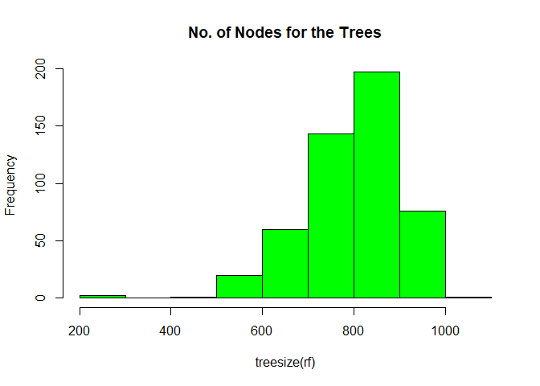

```r
hist(treesize(rf),
     main = "No. of Nodes for the Trees",
     col = "green")
```

[figure not shown]

```r
#Variable Importance
varImpPlot(rf,
           sort = T,
           n.var = 10,
           main = "Top 10 - Variable Importance")
```

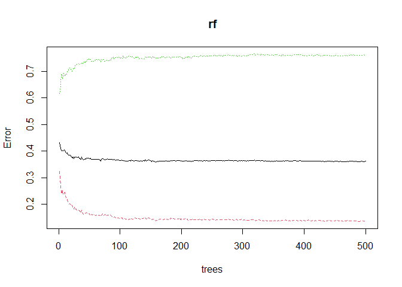

```r
plot(rf)
```

Tune my RF

```r
a=c()
i=7
for (i in 2:10) {

rf.tune <- randomForest(PregnancyOutcome_Live.Birth ~ Age + Gravidity +  FullTermBirths + Clinic.Region.USA +  MaleInfertility + Endometriosis  + Uterine + Unexplained +  OtherPGD + Unknowen + elect + Onco + OtherRFA + Medical.benign + Medical.Tumor.prevention + Syndromatic.DOR + SpermSource_Donor + NumberRetrieved_AutologousRetrieval1 +  Time_to.claim + total_n_fresh_cycles,
                    data= train.x ,
                    ntree= 400,
                    mtry=i,
                    importance= TRUE,
                    proximity=TRUE,
                    na.action=na.roughfix)

preValid <- predict(rf.tune, test.x, type = "class")
a[i-2] = mean(preValid == test.x$PregnancyOutcome_Live.Birth)
}
a
```

```
## [1] 0.6458716 0.6385321 0.6311927 0.6177370 0.6183486 0.6134557 0.6189602
## [8] 0.6122324
```

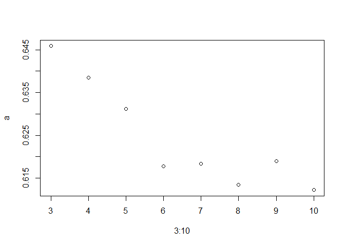

```r
plot(3:10, a)
```

Final Model

```r
rf.f <- randomForest(PregnancyOutcome_Live.Birth ~ Age + Gravidity +  FullTermBirths + Clinic.Region.USA +  MaleInfertility + Endometriosis  + Uterine + Unexplained +  OtherPGD + Unknowen + elect + Onco + OtherRFA + Medical.benign + Medical.Tumor.prevention + Syndromatic.DOR + SpermSource_Donor + NumberRetrieved_AutologousRetrieval1 +  Time_to.claim + total_n_fresh_cycles,
                    data= train.x ,
                    ntree= 400,
                    mtry=2,
                    proximity=TRUE,
                    na.action=na.roughfix,
                    trControl = trainControl(method = "cv", number=23 ))
# OtherNonInfertile + ThawedEmbryo + TransferAttempted + DonorIdentityKnown  + OtherRFA + SpermSource_Partner
```

```r
print(rf.f)
```

```
##
## Call:
##  randomForest(formula = PregnancyOutcome_Live.Birth ~ Age + Gravidity +      FullTermBirths + Clinic.Region.USA + MaleInfertility + Endometriosis +      Uterine + Unexplained + OtherPGD + Unknowen + elect + Onco +      OtherRFA + Medical.benign + Medical.Tumor.prevention + Syndromatic.DOR +      …
##                Type of random forest: classification
##                      Number of trees: 400
## No. of variables tried at each split: 2
##
##         OOB estimate of  error rate: 35.55%
## Confusion matrix:
##      0  1 class.error
## 0 3106 32  0.01019758
## 1 1711 54  0.96940510
```

```r
p.final.t <- predict(rf.f, train.x)
confusionMatrix(p.final.t, train.x$PregnancyOutcome_Live.Birth)
```

```
## Confusion Matrix and Statistics
##
##           Reference
## Prediction    0    1
##          0 3123 1667
##          1   15   98
##
##                Accuracy : 0.6569
##                  95% CI : (0.6435, 0.6702)
##     No Information Rate : 0.64
##     P-Value [Acc > NIR] : 0.00691
##
##                   Kappa : 0.0638
##
##  Mcnemar's Test P-Value : < 2e-16
##
##             Sensitivity : 0.99522
##             Specificity : 0.05552
##          Pos Pred Value : 0.65198
##          Neg Pred Value : 0.86726
##              Prevalence : 0.64002
##          Detection Rate : 0.63696
##    Detection Prevalence : 0.97695
##       Balanced Accuracy : 0.52537
##
##        'Positive' Class : 0
##
```

```r
p.final <- predict(rf.f, test.x)
confusionMatrix(p.final, test.x$PregnancyOutcome_Live.Birth)
```

```
## Confusion Matrix and Statistics
##
##           Reference
## Prediction    0    1
##          0 1046  564
##          1    8   17
##
##                Accuracy : 0.6502
##                  95% CI : (0.6265, 0.6733)
##     No Information Rate : 0.6446
##     P-Value [Acc > NIR] : 0.331
##
##                   Kappa : 0.0276
##
##  Mcnemar's Test P-Value : <2e-16
##
##             Sensitivity : 0.99241
##             Specificity : 0.02926
##          Pos Pred Value : 0.64969
##          Neg Pred Value : 0.68000
##              Prevalence : 0.64465
##          Detection Rate : 0.63976
##    Detection Prevalence : 0.98471
##       Balanced Accuracy : 0.51083
##
##        'Positive' Class : 0
##
```

```r
treeT1 <- table(predict(rf.f, test.x, type = 'class'), test.x$PregnancyOutcome_Live.Birth)
Accuracyrf <- (treeT1[1,1]+treeT1[2,2])/(sum(treeT1))
Accuracyrf
```

```
## [1] 0.6501529
```

## 3 Lasso

```r
# Install & load packages
if (!require(sas7bdat)) {install.packages("sas7bdat")}
if (!require(Hmisc)) {install.packages("Hmisc")}
if (!require(MASS)) {install.packages("MASS")}
if (!require(caret)) {install.packages("caret")}
if (!require(leaps)) {install.packages("leaps")}
if (!require(gamlr)) {install.packages("gamlr")}
if (!require(glmnet)) {install.packages("glmnet")}
```

Trim non factors before “hot-encoding”

```r
#trim missing
trim <- c("ExternalPatientID ", "ExternalCycleId ")
df <- df[, !(names(df) %in% trim)]

df <- subset(df, select = -c(3,4, 35:38, 40:41 ,45, 46, 49))
```

Data Partition

```r
## 75% of the sample size
smp_size <- floor(0.75 * nrow(df))
## set the seed
set.seed(1732)
train_ind <- sample(seq_len(nrow(df)), size = smp_size)

train.lasso <- df[train_ind, ]
test.lasso <- df[-train_ind, ]
```

Create the matrix of predictors and also automatically converts categorical predictors to dummy variables

```r
# Dumy code categorical predictor variables
x <- model.matrix(PregnancyOutcome_Live.Birth ~., train.lasso)[,-1]
y <- train.lasso$PregnancyOutcome_Live.Birth
```

Fit the lasso penalized regression model:

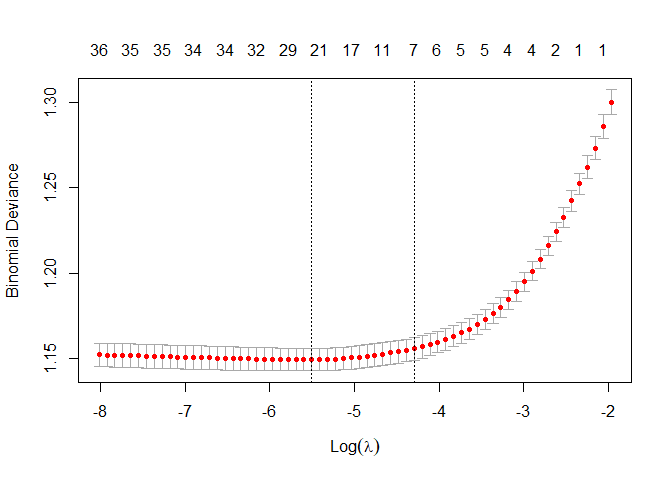

```r
# Find the best lambda using cross-validation
#Find the optimal value of lambda that minimizes the cross-validation error
set.seed(123)
cv.lasso <- cv.glmnet(x, y, alpha = 1, family = "binomial")
# Fit the final model on the training data
model <- glmnet(x, y, alpha = 1, family = "binomial",
                lambda = cv.lasso$lambda.min)
plot(cv.lasso)
```

```r
# Display regression coefficients
coef(model)
```

```
## 44 x 1 sparse Matrix of class "dgCMatrix"
##                                                       s0
## (Intercept)                                -2.588045e+00
## Clinic.Region.USANortheast                 -8.391288e-02
## Clinic.Region.USASouth                      6.429167e-02
## Clinic.Region.USAWest                       1.353513e-01
## ReportingYear2015                          -5.391895e-02
## ReportingYear2016                           .
## ReportingYear2017                          -7.337966e-02
## ReportingYear2018                           1.232919e-02
## ReportingYear2019                           .
## Age                                        -3.589161e-02
## DonorIdentityKnown1                         .
## Gravidity                                  -3.912968e-02
## FullTermBirths                              5.504744e-02
## MaleInfertility1                            .
## Endometriosis1                              .
## PolycysticOvaries1                          .
## DiminishedOvarianReserve1                  -1.066338e-01
## TubalLigation1                              .
## TubalHydrosalpinx1                          .
## TubalOther1                                 .
## Uterine1                                    6.370508e-02
## Unexplained1                                .
## OtherRFA1                                  -1.277837e-01
## OtherNonInfertile1                         -8.826597e-03
## OtherPGD1                                   .
## Unknowen1                                   .
## elect1                                      .
## Onco1                                       .
## Medical.benign1                            -6.411613e-02
## Medical.Tumor.prevention1                   .
## Syndromatic.DOR1                            .
## DOR..351                                   -2.110633e-02
## FreshEmbryo1                               -3.025965e-01
## ThawedEmbryo1                               .
## ThawedOocyte1                              -4.464627e-04
## SpermSource_Partner1                       -2.431653e-01
## SpermSource_Donor1                          .
## SpermSource_Mixed1                          .
## TransferAttempted1                          3.446392e+00
## NumberRetrieved_AutologousRetrieval1        6.646750e-03
## NumberThawed_AutologousRetrieval1           2.142204e-02
## ThawDateStartDateDiff_AutologousRetrieval1  .
## total_n_fresh_cycles                       -1.546996e-02
## Time_to.claim                               1.202538e-05
```

```r
# Make predictions on the test data
x.test <- model.matrix(PregnancyOutcome_Live.Birth ~., test.lasso)[,-1]
probabilities <- model %>% predict(newx = x.test)
predicted.classes <- ifelse(probabilities > 0.5, "1", "0")
# Model accuracy
observed.classes <- test.lasso$PregnancyOutcome_Live.Birth
mean(predicted.classes == observed.classes)
```

```
## [1] 0.6287462
```

```r
cv.lasso$lambda.min
```

```
## [1] 0.004069824
```

```r
cv.lasso$lambda.1se
```

```
## [1] 0.01364043
```

```r
coef(cv.lasso, cv.lasso$lambda.min)
```

```
## 44 x 1 sparse Matrix of class "dgCMatrix"
##                                                       s1
## (Intercept)                                -2.586293e+00
## Clinic.Region.USANortheast                 -8.408450e-02
## Clinic.Region.USASouth                      6.408261e-02
## Clinic.Region.USAWest                       1.351380e-01
## ReportingYear2015                          -5.397522e-02
## ReportingYear2016                           .
## ReportingYear2017                          -7.338561e-02
## ReportingYear2018                           1.235115e-02
## ReportingYear2019                           .
## Age                                        -3.588671e-02
## DonorIdentityKnown1                         .
## Gravidity                                  -3.930799e-02
## FullTermBirths                              5.523349e-02
## MaleInfertility1                            .
## Endometriosis1                              .
## PolycysticOvaries1                          .
## DiminishedOvarianReserve1                  -1.066847e-01
## TubalLigation1                              .
## TubalHydrosalpinx1                          .
## TubalOther1                                 .
## Uterine1                                    6.372669e-02
## Unexplained1                                .
## OtherRFA1                                  -1.277893e-01
## OtherNonInfertile1                         -8.772398e-03
## OtherPGD1                                   .
## Unknowen1                                   .
## elect1                                      .
## Onco1                                       .
## Medical.benign1                            -6.409242e-02
## Medical.Tumor.prevention1                   .
## Syndromatic.DOR1                            .
## DOR..351                                   -2.107302e-02
## FreshEmbryo1                               -3.045325e-01
## ThawedEmbryo1                               .
## ThawedOocyte1                               .
## SpermSource_Partner1                       -2.424167e-01
## SpermSource_Donor1                          .
## SpermSource_Mixed1                          .
## TransferAttempted1                          3.444696e+00
## NumberRetrieved_AutologousRetrieval1        6.640387e-03
## NumberThawed_AutologousRetrieval1           2.147974e-02
## ThawDateStartDateDiff_AutologousRetrieval1  .
## total_n_fresh_cycles                       -1.526808e-02
## Time_to.claim                               1.213014e-05
```

Compute the final lasso modelusing lambda.min:

```r
# Final model with lambda.min
lasso.model <- glmnet(x, y, alpha = 1, family = "binomial",
                      lambda = cv.lasso$lambda.min)
# Make prediction on test data
x.test <- model.matrix(PregnancyOutcome_Live.Birth ~., test.lasso)[,-1]
probabilities.lasso <- lasso.model %>% predict(newx = x.test)
predicted.classes.lasso <- ifelse(probabilities > 0.5, "1", "0")
# Model accuracy
observed.classes.lasso <- test.lasso$PregnancyOutcome_Live.Birth
Accuracy_lasso <- mean(predicted.classes.lasso == observed.classes.lasso)
```

Compute the full logistic model

```r
# Fit the model
log.model <- glm(PregnancyOutcome_Live.Birth ~., data = train.lasso, family = binomial)
# Make predictions
probabilities.reg <- log.model %>% predict(test.lasso, type = "response")
predicted.classes.reg <- ifelse(probabilities > 0.5, "1", "0")
# Model accuracy
observed.classes.reg <- test.lasso$PregnancyOutcome_Live.Birth
mean(predicted.classes.reg == observed.classes.reg)
```

```
## [1] 0.6287462
```